# Facets and Geoms

### 3.5.1 Exercises

1. What happens if you facet on a continuous variable?

This does not throw an error, but the data is broken into many subsets and shown in many plots that practically is useless and very hard to interpret. For instance, let’s look at the relationship between highway and city fuel efficinecy faceted on engine size.

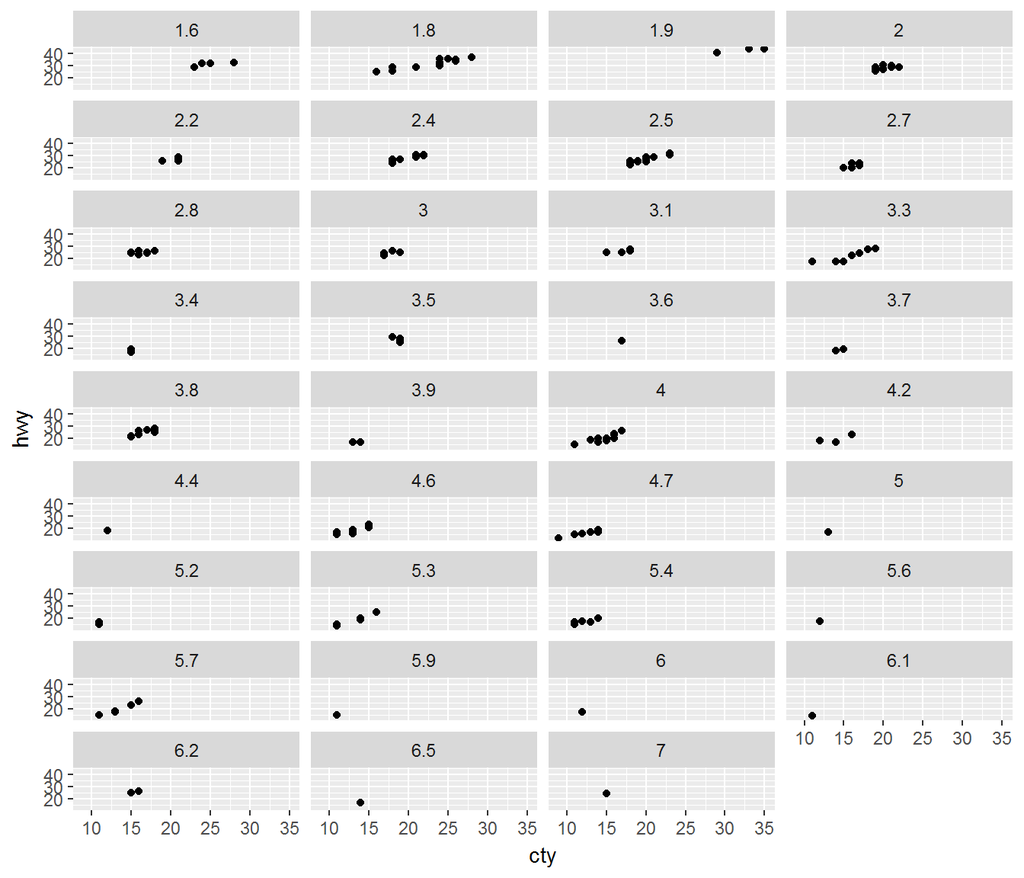

```r
ggplot(data = mpg) +
  geom_point(mapping = aes(x = cty, y = hwy)) +
  facet_wrap(~ displ, ncol = 4)
```

2. What do the empty cells in plot with `facet_grid(drv ~ cyl)` mean? How do they relate to this plot?

The empty plot means that there has been no data at the intersection of the two faceted variables. For instance, Looking at the left figure below, it can be seen that there is no data at the intersections of `(cyl = 5, drv = "4")`, `(cyl = 5, drv = "r")`, and `(cyl = 4, drv = "r)`. The same idea can be taken from the scatter plot of `cyl` vs. `drv`.

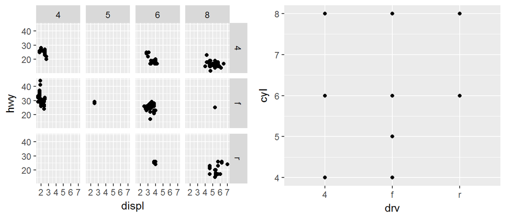

```r
library(gridExtra)
ggplot(data = mpg) +
  geom_point(mapping = aes(x = displ, y = hwy)) +
  facet_grid(drv ~ cyl) -> p1

ggplot(data = mpg) +
  geom_point(mapping = aes(x = drv, y = cyl)) -> p2

grid.arrange(p1, p2, ncol = 2)
```

3. What plots does the following code make? What does `.` do?

`.` makes the plot not facet on either columns (`X ~ .`) or rows (`. ~ X`). For instance, the following plots are not faceted on rows and on columns respectively.

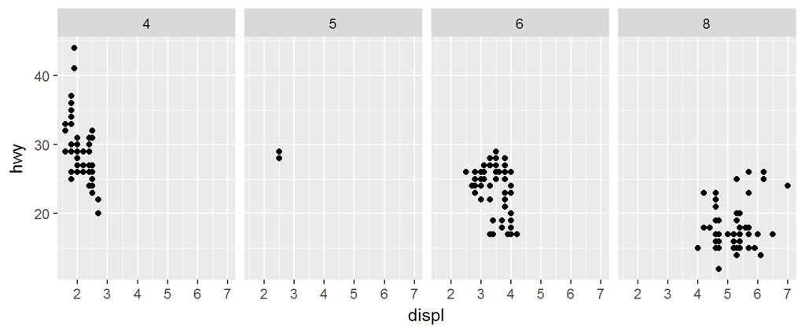

```r
ggplot(data = mpg) +
  geom_point(mapping = aes(x = displ, y = hwy)) +
  facet_grid(. ~ cyl)
```

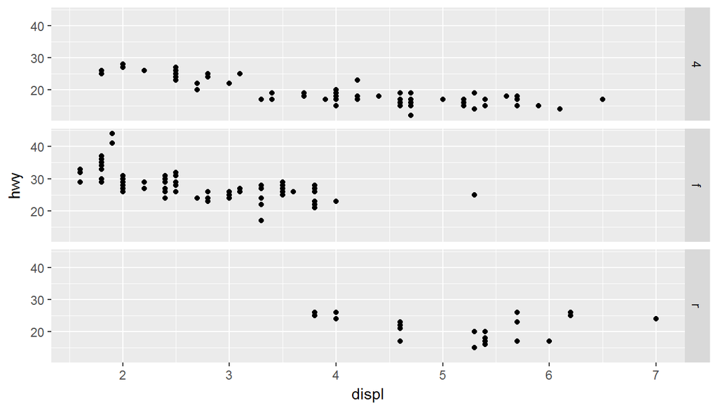

```r
ggplot(data = mpg) +
  geom_point(mapping = aes(x = displ, y = hwy)) +
  facet_grid(drv ~ .)
```

4. Take the first faceted plot in this section:

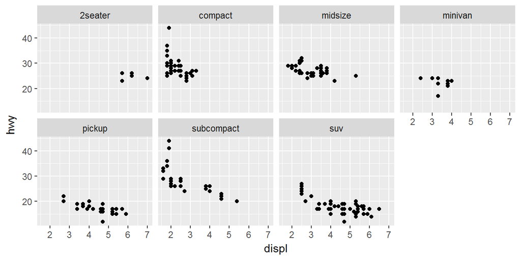

What are the advantages to using faceting instead of the colour aesthetic? What are the disadvantages? How might the balance change if you had a larger dataset?

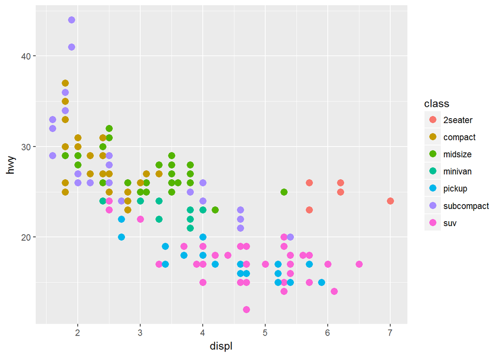

```r
ggplot((dat = mpg)) +
  geom_point(mapping = aes(x = displ, y = hwy, color = class), size = 3)
```